```python
import pandas as pd
import numpy as np
import seaborn as sns
import matplotlib.pyplot as plt
from sklearn.model_selection import train_test_split, GridSearchCV
from sklearn.feature_selection import VarianceThreshold
from sklearn.preprocessing import StandardScaler, normalize
from sklearn.linear_model import LogisticRegression
from sklearn.metrics import confusion_matrix, accuracy_score, classification_report
from sklearn.ensemble import RandomForestClassifier
from sklearn.cluster import KMeans
import math
import itertools
```

# Project Introduction

For this project, we will be using the **Wine Quality Dataset** from the [UCI Machine Learning Repository](https://archive.ics.uci.edu/ml/datasets/wine+quality). The dataset contains different charactersitics of several Portugese wines. `Quality` is the dependent variable. Better quality wines have a score of 10 while the lowest quality wine has a score of 0. The predictors of the wine are:

- `Fixed Acidity`
- `Volatile Acidity`
- `Citric Acid`
- `Residual Sugar`
- `Chlorides`
- `Free Sulfur Dioxide`
- `Total Sulfur Dioxide`
- `Density`
- `pH`
- `Sulphates`
- `Alcohol`

Originally, we had 2 different datasets consiting of white wine and red wine. I will combine the two and make `color_red` a predictor.

Using this dataset, we will attempt categorize wines by their quality. We will use several methods such as an unsupervised kmeans, random forest, support vector machines, multinomial logistic regression

```python
red_wine = pd.read_csv("data/winequality-red.csv", sep=";")
white_wine = pd.read_csv("data/winequality-white.csv", sep=";")

#Create Color Predictor
red_wine["color_red"] = 1
white_wine["color_red"] = 0

#Combine Datasets
df = pd.concat([red_wine, white_wine])
```

# Data Description

```python
df.shape
```

```
(6497, 13)
```

```python
df.isnull().sum()
```

```
fixed acidity           0
volatile acidity        0
citric acid             0
residual sugar          0
chlorides               0
free sulfur dioxide     0
total sulfur dioxide    0
density                 0
pH                      0
sulphates               0
alcohol                 0
quality                 0
color_red               0
dtype: int64
```

```python
df.head()
```

|  | fixed acidity | volatile acidity | citric acid | residual sugar | chlorides | free sulfur dioxide | total sulfur dioxide | density | pH | sulphates | alcohol | quality | color_red |
| --- | --- | --- | --- | --- | --- | --- | --- | --- | --- | --- | --- | --- | --- |
| 0 | 7.4 | 0.70 | 0.00 | 1.9 | 0.076 | 11.0 | 34.0 | 0.9978 | 3.51 | 0.56 | 9.4 | 5 | 1 |
| 1 | 7.8 | 0.88 | 0.00 | 2.6 | 0.098 | 25.0 | 67.0 | 0.9968 | 3.20 | 0.68 | 9.8 | 5 | 1 |
| 2 | 7.8 | 0.76 | 0.04 | 2.3 | 0.092 | 15.0 | 54.0 | 0.9970 | 3.26 | 0.65 | 9.8 | 5 | 1 |
| 3 | 11.2 | 0.28 | 0.56 | 1.9 | 0.075 | 17.0 | 60.0 | 0.9980 | 3.16 | 0.58 | 9.8 | 6 | 1 |
| 4 | 7.4 | 0.70 | 0.00 | 1.9 | 0.076 | 11.0 | 34.0 | 0.9978 | 3.51 | 0.56 | 9.4 | 5 | 1 |

```python
#Change quality to categorical type
df['quality'] = df['quality'].astype('category')
df.info()
```

```
<class 'pandas.core.frame.DataFrame'>
Int64Index: 6497 entries, 0 to 4897
Data columns (total 13 columns):
 #   Column                Non-Null Count  Dtype
---  ------                --------------  -----
 0   fixed acidity         6497 non-null   float64
 1   volatile acidity      6497 non-null   float64
 2   citric acid           6497 non-null   float64
 3   residual sugar        6497 non-null   float64
 4   chlorides             6497 non-null   float64
 5   free sulfur dioxide   6497 non-null   float64
 6   total sulfur dioxide  6497 non-null   float64
 7   density               6497 non-null   float64
 8   pH                    6497 non-null   float64
 9   sulphates             6497 non-null   float64
 10  alcohol               6497 non-null   float64
 11  quality               6497 non-null   category
 12  color_red             6497 non-null   int64
dtypes: category(1), float64(11), int64(1)
memory usage: 666.5 KB
```

Before we continue, we need to separate our data into a training, validation and test sets.

```python
# Split into Training and Test set
temp_train, test_df = train_test_split(df, test_size=0.1, random_state=2564)
train_df, valid_df = train_test_split(temp_train, test_size=0.2, random_state=1815)
```

# Initial EDA and Feature Selection

- Look at each predictor in relation to `quality`
- Look at multicollinearity

## Count by Quality

A majority of wines are rated as an average win of slighlty above average. We can also see that no one is rated as a perfect 10 or an abysmal score of 2 or lower. The distribution shows that recieving a score of 1,2 or 10 is exteremely rare. Thus, the wines rated as such will be misclassified. However, if more data is collected we will be able to expand our model to include those scores

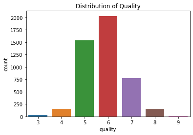

```python
sns.countplot(x='quality', data=train_df)
plt.title("Distribution of Quality")
```

## Correlation

It is important we look at the correlation of the predictors. Highly correlated predictors could mean our predictors are providing redundant information. Some models are highly inaccurate when predictors face this issue. For example, Logistic Regression is a Generalized Linear Model (GLM). Thus, multicollinearity could cause inaccurracies with predictors. This can hurt the interpretability of our model. Sometimes, the collinearity issues cause the model to fail in converging into a unique solution. Also, models such as K-means suffer from the curse of dimensionality. Therefore, reducing the number of predictors could help performance.

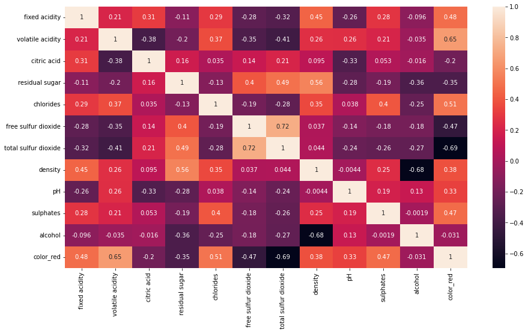

```python
plt.figure(figsize = (15,8))
sns.heatmap(train_df.corr(), annot=True)
```

## Continuous Predictors

Most of our predictors are normally distributed. However,`volatile acidity` and `residual sugar` are slightly skewed to the right. By themeselves, the distributions are quite concerning. However, for some models, such as random forest, the distribution of predictors isn't as concerning. However, for logistic regression, we need to make sure there are no outliers among the predicors. For models such as K-means, we need to standardize our predictors so that one feature isn't contributing more to the distance measures than others. For example, `fixed acidity` has a range of 0-16 units. However, `volatile acidity` has a range from 0-1.6. When calculating distance measures in K-means, fixed acidity will count more towards the distance measure than `volatile acidity`. At this time, we will not apply transformations to our predictor variables. **We'll only apply transformations to meet the assumptions of the model when using**.

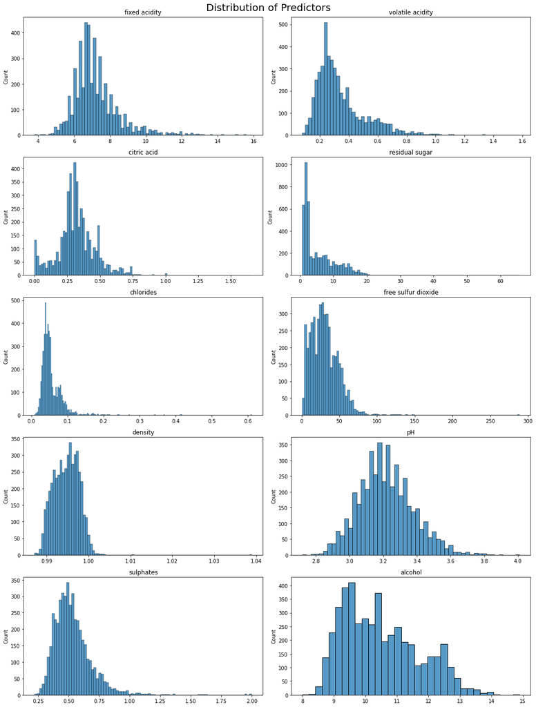

```python
predictors = train_df.drop(['quality', 'color_red'], axis=1).columns

fig, ax = plt.subplots(math.ceil(len(predictors)/2), 2, figsize=(15,20))

for i in range(len(predictors)):

    row = math.floor(i/2)
    col = i % 2
    sns.histplot(train_df[predictors[i]], ax=ax[row, col])

    #Set title for each subplot
    ax[row,col].set_title(predictors[i])
    ax[row,col].set_xlabel(None)

_ = fig.suptitle("Distribution of Predictors", fontsize=20)
fig.tight_layout()
```

## Continuous Predictors vs `Quality`

Next, we would like to visualize each continuous predictor vs our response variable `quality`. We would be concerened with a predictors if the distributions per level of `quality` were the same. If a predictor had the same distribution per level of quality, we will know the predictor doesn't add much value in prediction.

As we can see below, each predictor has different distributions per level of quality. Here are some key points shown by the boxplots:

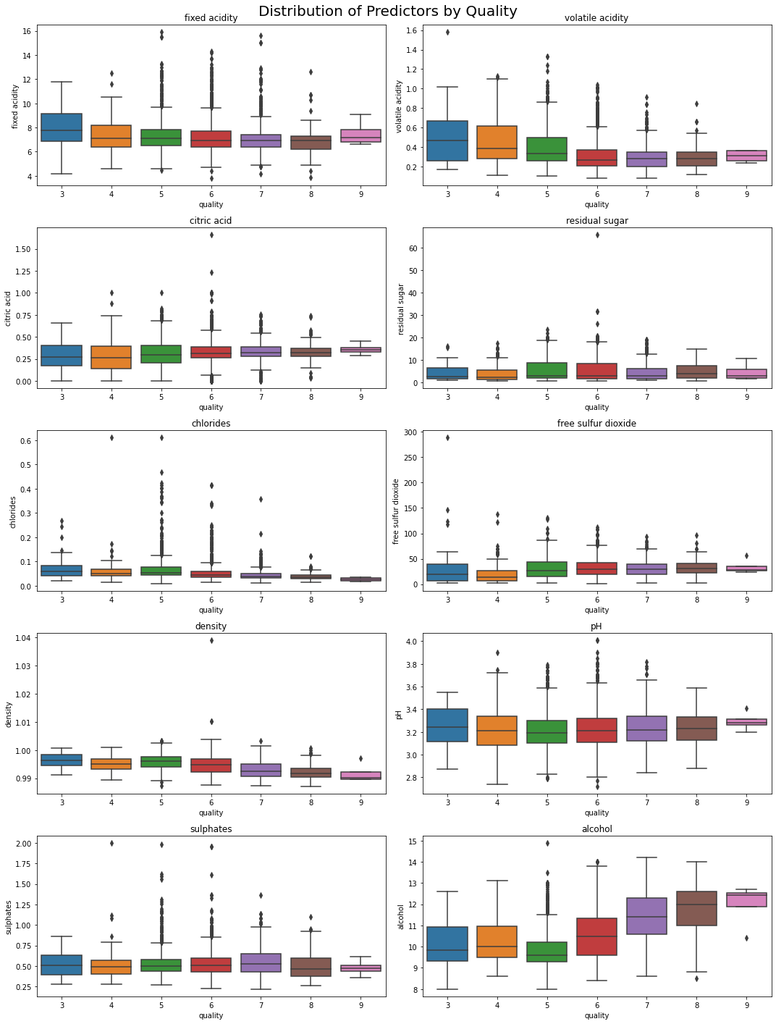

```python
#Get all strings for names of continuous predictors
predictors = train_df.drop(['quality', 'color_red', "total sulfur dioxide"], axis=1).columns

fig, ax = plt.subplots(math.ceil(len(predictors)/2), 2, figsize=(15,20))

for i in range(len(predictors)):
    #Get row and column position for subplots
    row = math.floor(i/2)
    col = i % 2

    #Get predictor and plot boxplots
    predictor = predictors[i]
    sns.boxplot(x='quality', y=predictor, data=train_df, ax=ax[row,col])

    #Set title for each subplot
    ax[row,col].set_title(predictor)


fig.suptitle("Distribution of Predictors by Quality", fontsize=20)
fig.tight_layout()
```

## `Color_red`

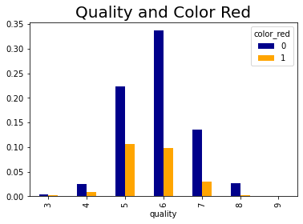

```python
pd.crosstab(train_df['quality'], train_df['color_red'], normalize=True).plot(kind="bar", color=["darkblue", "orange"])
plt.title("Quality and Color Red", fontsize=20)
```

```python
#Drop color_red

train_df.drop(['color_red'], axis=1, inplace=True)
test_df.drop(['color_red'], axis=1, inplace=True)
valid_df.drop(['color_red'], axis=1, inplace=True)
```

# Model Candidates

For our dataset, we will attempt to build the following models:

- Multi-nomial Logistic Regression
  - We want to build this model because it is the mode interpretable. If we can build a model that is highly interpretable, we can understand how different factors contribute to wine quality classification
- K-means Clustering
  - Using a non parameteric method may work better on our dataset. We have a small amount of predictors so we won't face the curse of dimensionality
  - On the other end, our dataset has an unequal count in the levels of response variable. With using `k-means` as an unsupervised method, this can cause issues with clustering accurately.
- Random Forest
  - Random Forest is another nonparametric method. However, it builds a forest of decision trees by selecting a subset of features to buil don each tree.
  - The most chosen level from all the trees will classify the observation

Because our data has small dimensionality with predictors we can transform, k-means seems as it would perform well. After further looking into the response variable distribution, I believe it would be the worse predictor of the three. On the other hand, I believe Random Forest will perform the best as it can catch interactions we may not find in Logistic Regression and the uneven distribution isn't as large as problem as k-means.

**Accuracy will be used to compare the three different models as we are more concerned with classifying with the correct class than Type I or Type II error**

### Logistic Regression

First, we need to train a logistic regression model. After fitting, the model has an accuracy of 54.27%

```python
#Create Training and Validation Sets
X_train = train_df.drop('quality', axis=1)
y_train = train_df['quality']
X_valid = valid_df.drop('quality', axis=1)
y_valid = valid_df['quality']
```

```python
#Standardize Data
scaler = StandardScaler()
X_train_std = scaler.fit_transform(X_train)
X_valid_std = scaler.transform(X_valid)
```

```python
model = LogisticRegression(max_iter=300)
model.fit(X_train_std, y_train)
```

```
LogisticRegression(max_iter=300)
```

```python
preds = model.predict(X_valid_std)
```

```python
accuracy_score(y_valid, preds)
```

```
0.5427350427350427
```

### Random Forest

```python
#Fit Random Forest
model2 = RandomForestClassifier(random_state=73845)
model2.fit(X_train, y_train)
```

```
RandomForestClassifier(random_state=73845)
```

```python
preds2 = model2.predict(X_valid)
```

```python
accuracy_score(y_valid, preds2)
```

```
0.6743589743589744
```

### K-means Clustering

As expected, k-means performs poorly with 21.19% accuracy.

```python
#Compare different permutations to get the correct one
def label_permutation(labels, cluster_labels):
    """
    labels: labels dataframe object
    cluster_labels: clustering label prediction output
    n : the number of clusters
    Returns permuted label order and accuracy.
    """
    perms = list(itertools.permutations(labels.unique()))
    acc=[]
    for i in range(len(perms)):
        mapdict = dict(zip(list(y_train.unique()),list(perms[i])))
        yt = labels.apply(lambda x: mapdict[x])
        acc.append(accuracy_score(yt, cluster_labels))
    idx = np.argmax(acc)
    return perms[idx], acc[idx]
```

```python
model3 = KMeans(7).fit(X_train_std)
```

```python
label_order, acc = label_permutation(y_train, model3.labels_)
```

```python
acc
```

```
0.21188796236903998
```

### Model Comparison and Analysis

| Model | Accuracy |
| --- | --- |
| Logistic Regression | 54.27% |
| Random Forest | 67.44% |
| K-means | 21.19% |

- As expected, K-means performed the worst at 21.19%. K-means fails when there aren't equal observations for each class. In our case, most of our data belonged to the class of 5 and 6. On the other hand, there were barely any observations for a quality of 3, 4, 8 or 9. Thus, the algorithm couldn't accurately convere on a stable mean compared to qualitied of 5 and 6.
- Multinomial. Logistic Regression performed ok. The lack of interactions and other transformations that could have been applied causes the lack of accuracy. However, the multinomial is more difficult to interpret compared to Binary Logistic Regression or Random Forest. This is even more true after we standardized the predictors.
- Random Forest Performed the best. The model was able to capture interaction between predictors. Also, because of the use of subsets within different trees, we can interpret the most important factors used with decision making.

Thus, going forward we will use the Random Forest Model

# Model Tuning

Random Forest Models are known for over fitting. We need to evaluate our model using different hyperparameters and predictors subsets. Not only will this help with generalization, it will also improve our model speed.

We can use `GridSearchCV` to find the best combination of hyperparameters.

Some parameters we will fine tune are:

- `criterion`: what to use as measurement within the tree
- `Max Depth`: The maximum number of levels for each decision tree
- `Max features`: the number of features to consider for each decision tree within the forest
- `Min_samples_split`: the minimum number of observations required to split a branch
- `n_estimators`: the number of trees to use in the forest.

After GridSearch we can see our model improved by about 1.2%.

```python
#Dictionary of possible hyperparameters
param_grid = {
    'criterion': ["entropy", "gini"]
    'max_depth': [4, 8, 12],
    'max_features': ["auto", "sqrt", "log2", 0.5],
    'min_samples_leaf': [3, 5, 10],
    'min_samples_split': [5, 10, 20],
    'n_estimators': [ 200, 400, 600, 800]
}

rf = RandomForestClassifier()
```

```python
grid_search = GridSearchCV(estimator = rf, param_grid = param_grid,
                          cv = 3, n_jobs = -1, verbose = 2)
```

```python
# grid_search.fit(X_train, y_train)
# grid_search.best_params_

#Best Fit
# 'max_depth': 20,
#  'max_features': 0.5,
#  'min_samples_leaf': 1,
#  'min_samples_split': 5,
#  'n_estimators': 1250
# criterion: "gini"
```

```python
#Create final model with hyper paramters
final_model = RandomForestClassifier(random_state=46244, max_depth=20, max_features=0.5,
                                    min_samples_leaf=1, min_samples_split=5, n_estimators=1250, criterion="gini")
final_model.fit(X_train, y_train)
final_preds = final_model.predict(X_valid)
```

```python
accuracy_score(y_valid, final_preds)
```

```
0.6863247863247863
```

# Final Model Evaluation

```python
#Create test sets
X_test = test_df.drop('quality', axis=1)
y_test = test_df['quality']
```

```python
test_preds = final_model.predict(X_test)
```

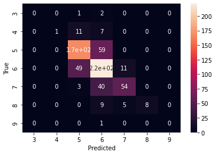

```python
cm = confusion_matrix(y_test, test_preds)

sns.heatmap(cm, annot=True, xticklabels=np.unique(y_test), yticklabels=np.unique(y_test))
_= plt.ylabel("True")
_ = plt.xlabel("Predicted")
```

```python
print(classification_report(y_test, test_preds))
```

```
              precision    recall  f1-score   support

           3       0.00      0.00      0.00         3
           4       1.00      0.05      0.10        19
           5       0.72      0.74      0.73       227
           6       0.65      0.79      0.71       281
           7       0.77      0.56      0.65        97
           8       1.00      0.36      0.53        22
           9       0.00      0.00      0.00         1

    accuracy                           0.70       650
   macro avg       0.59      0.36      0.39       650
weighted avg       0.71      0.70      0.68       650
```

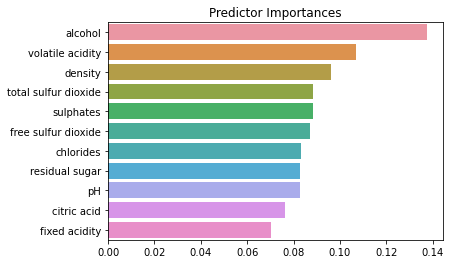

```python
#Plot feature importances
importances = pd.Series(final_model.feature_importances_, index=X_train.columns).sort_values(ascending=False)
sns.barplot(importances, importances.index)

_ = plt.title("Predictor Importances")
```

# Conclusion and Recommendation for Future Project

- Overall, our model performs well for wine qualities of 5,6,7. However, due to lack of data, it fails to classify quality of 3,4,8 or 9 correctly. We didn't have any values of wine quality of 1, 2 or 10. Thus, that is another issue with the dataset we had
- When discussing quality wine, `alcohol content` is the most important factor followed by `volatile acidity`
- The least important predictors are `fixed acidity` and `citric acid`
- For future projects
  - more wine would need to be collected to accurately represent the different qualities in the distribution.
  - With more wines, other models such as Logistic Regression may converge to a better model
  - May need to deparate `quality` into a binary category. Higher than 5 is a good wine while 5 or lower it bad. This may result in classifying if a wine is strictly good or not